# Regression

4/20/2020

This question was asked by: Upstart Suppose we have two variables, X and Y, where Y = X + some normal white noise. 1. What will our coefficient be of we run a regression of Y on X? 2. What happens if we run a regression of X on Y?

We are going to dig into this a bit beyond the basis of the question and look at the ways that Y & X can have relationship. First lets look at set of randomized, independent data on a standard Cartesian plane.

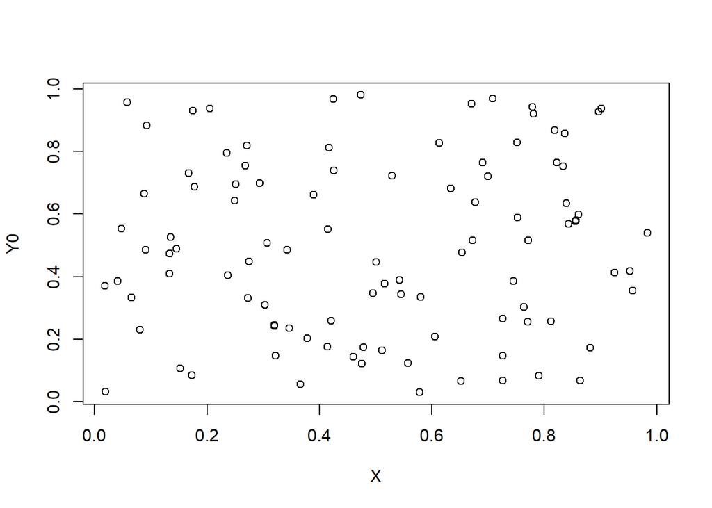

```r
# runif will create a set of randomized data in a uniform distribution
# runif(x,y,z): x - number of events, y - minimum value, z - maximum value
X = runif(100,0,1)
# We are going to order x, so we will always see the x axis as a minimum to maximum order on the plot
X = X[order(X)]
Y0 = runif(100,0,1)

plot(y = Y0, x = X)
```

This plot is a set of random noise. THe points are random, and any patterns that emerge would be spurious. Now, lets see what happens if we make Y have a dependent relationship to X. We’ll start with the same X, but now create Y using X.

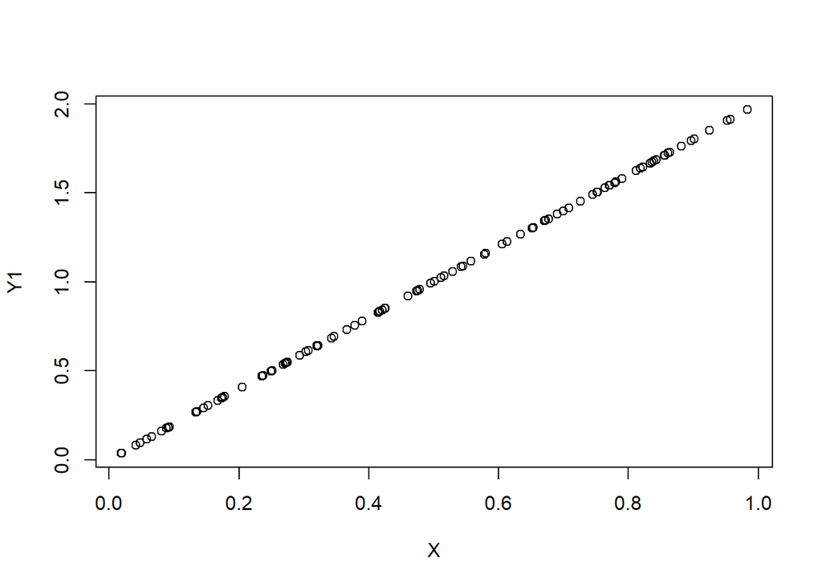

```r
# we'll carry the same X, but now make Y dependent on X
Y1 = X * 2

plot(y = Y1, x = X)
```

Here we can see a perfect relationship, and for every point on X, there is a coresponding Y value that is 2*X. This would be notated as the slope of the line, or y = 2x+0 [ y = mx + b].

Now, if we added in some real world noise…

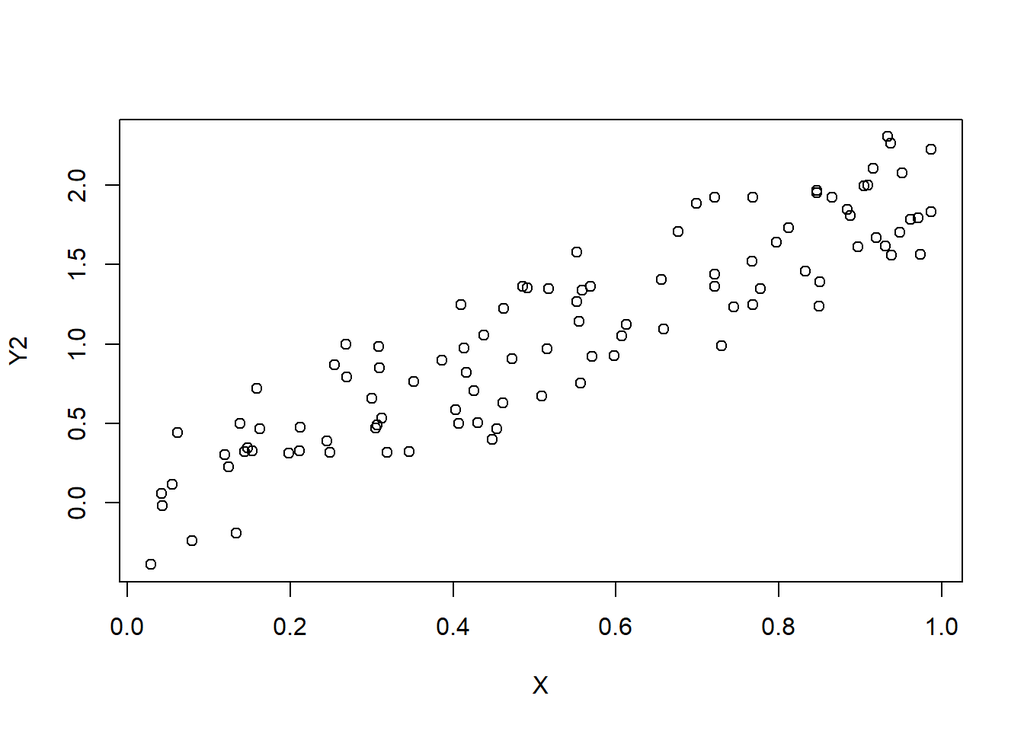

```r
X = runif(100,0,1)
X = X[order(X)]
Y2 = X * 2 + runif(100,-.5,.5)

plot(y = Y2, x = X)
```

The regression is an esimation of beta and what the remainder of epsilon is the error.

Now we can add a regression on that data set:

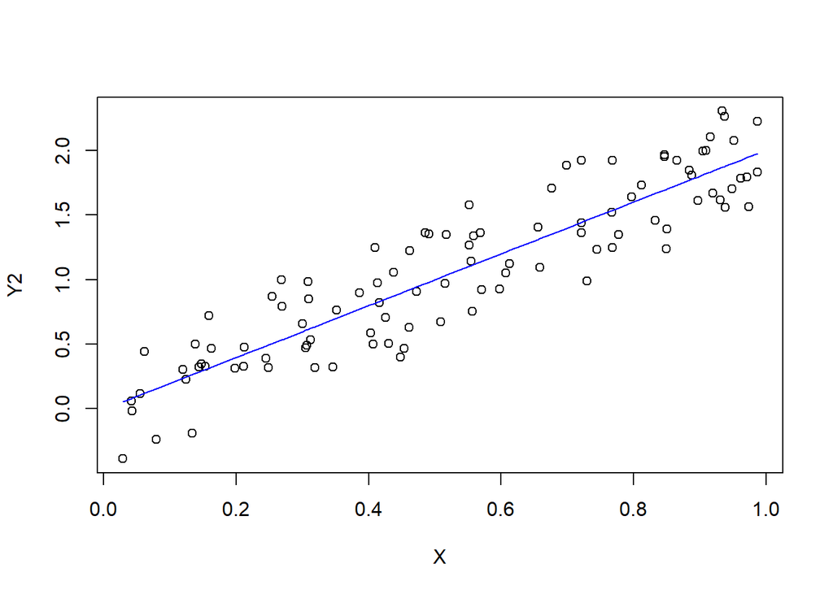

```r
# We'll use the linear model function which is form of Y~X or Y = f(X)
LinReg = lm(Y2~X)

plot(y = Y2, x = X)
lines(x = X, y = predict(LinReg), col = 'blue')
```

We can see the line running through the points. We can take a look at the details of the linear regression to see how it picks that line.

```r
summary(LinReg)
```

```
##
## Call:
## lm(formula = Y2 ~ X)
##
## Residuals:
##      Min       1Q   Median       3Q      Max
## -0.49454 -0.20792 -0.00731  0.22088  0.48886
##
## Coefficients:
##              Estimate Std. Error t value Pr(>|t|)
## (Intercept) -0.007087   0.056734  -0.125    0.901
## X            2.012094   0.093344  21.556   <2e-16 ***
## ---
## Signif. codes:  0 '***' 0.001 '**' 0.01 '*' 0.05 '.' 0.1 ' ' 1
##
## Residual standard error: 0.2679 on 98 degrees of freedom
## Multiple R-squared:  0.8258, Adjusted R-squared:  0.824
## F-statistic: 464.7 on 1 and 98 DF,  p-value: < 2.2e-16
```

Therefore the estmated line is y = 2x+0, which is what the line was before we added the noise.

The extra data is very important and the difference between a good model and a junkie one. The Std. Error is the standard deviation of the estimated X variable(s) and intercept. Its a measure of how likely the mean of the estimate is from 0. The t-value is the number of standard deviations from zero the estimate is given the standard error on Student’s t-distrubtion.  
The p-value is the probability that the estimate is not 0. It is NOT an estimate that the value is correct. The t-value and p-value are related and the larger the abs(t-value), the smaller the p-value.

In this case R present a nice code of ‘’, ‘.’, ’*’, etc. And this signifies what level we state the value is signicant. A 0.05 signicance means that we believe it to be 95% probability to not be 0. A general rule of thumb is 95% for any value you are working with, or a p-value of .05.

Now, lets run the linear regression for the first set of data.

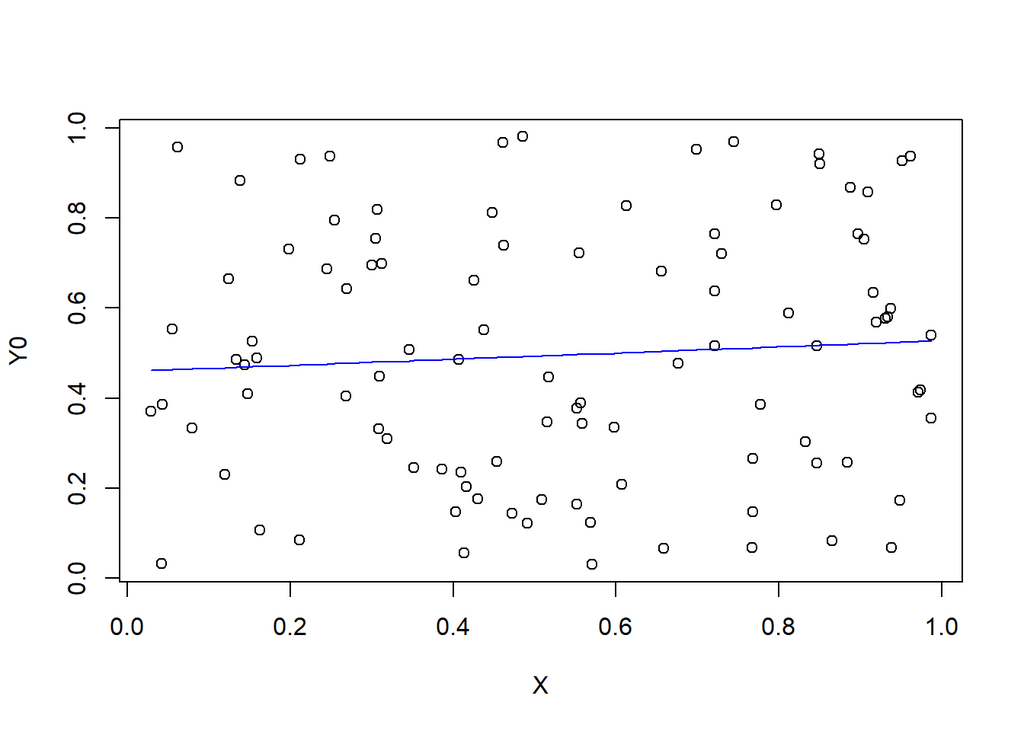

```r
LinReg0 = lm(Y0~X)

plot(y = Y0, x = X)
lines(x = X, y = predict(LinReg0), col = 'blue')
```

```r
summary(LinReg0)
```

```
##
## Call:
## lm(formula = Y0 ~ X)
##
## Residuals:
##      Min       1Q   Median       3Q      Max
## -0.46754 -0.23904  0.00202  0.22664  0.49426
##
## Coefficients:
##             Estimate Std. Error t value Pr(>|t|)
## (Intercept)  0.45930    0.05918   7.761 8.17e-12 ***
## X            0.06789    0.09737   0.697    0.487
## ---
## Signif. codes:  0 '***' 0.001 '**' 0.01 '*' 0.05 '.' 0.1 ' ' 1
##
## Residual standard error: 0.2795 on 98 degrees of freedom
## Multiple R-squared:  0.004936,   Adjusted R-squared:  -0.005218
## F-statistic: 0.4861 on 1 and 98 DF,  p-value: 0.4873
```

So linear regressions are important to understand and read before using. More time should be spent looking at the other data, the residuals, R-squared, and others.